# Data 607 Project 2, File 2

Ken Popkin

3/9/2020

## Assignment Summary

For Project 2, choose any three of the “wide” datasets identified in the Week 6 Discussion items. This document contains the second of the three files selected for this assignment.

File selected: Undergraduate and Graduate Enrollment submitted by Christian Thieme. [link to undergraduate and graduate rates](https://nces.ed.gov/ipeds/Search/ViewTable?tableId=12607&returnUrl=%2Fipeds%2FSearch)

Analysis to perform: Look at enrollment trends over time by region (south, west, etc.) or state to see if enrollment is dropping in any state/region. Provide narrative descriptions of the data cleanup work and analysis completed, along with conclusions about the data.

## Setup and load data

```r
library(dplyr)
library(tidyr)
library(data.table)
library(ggplot2)
```

```r
#Load the data
data <-  read.csv('undergraduate_and_graduate_enrollment.csv', skip=12, header = FALSE)

data <- data %>% `colnames<-`(c('state', 'y06_07', 'y07_08', 'y08_09', 'y09_10', 'y10_11', 'y11_12', 'y12_13', 'y13_14'))

head(data,4)
```

```
##      state y06_07  y07_08  y08_09  y09_10  y10_11  y11_12  y12_13  y13_14
## 1  Alabama 342574  371246  400252  422232  433128  425830  411484  404178
## 2   Alaska  53577   54722   54322   58796   59899   61426   56900   55691
## 3  Arizona 886437 1037381 1094710 1225962 1261725 1182570 1093714 1026351
## 4 Arkansas 197516  203240  214238  228930  235557  238179  230809  224149
```

```r
#Load the regions
regions <- read.csv('Census_Regions_and_Divisions.csv')
regions <- select(regions, State, Region)
regions <- regions %>% `colnames<-`(c('state', 'region'))
head(regions, 2)
```

```
##     state region
## 1 Alabama  South
## 2  Alaska   West
```

## Tidy up the data

```r
#Merge the region column with the graduation rates
data2 <- merge(data, regions, by.x = "state", by.y = "state")
head(data2,2)
```

```
##     state y06_07 y07_08 y08_09 y09_10 y10_11 y11_12 y12_13 y13_14 region
## 1 Alabama 342574 371246 400252 422232 433128 425830 411484 404178  South
## 2  Alaska  53577  54722  54322  58796  59899  61426  56900  55691   West
```

```r
#Convert the undergraduate and graduate yearly data from a wide to long format
yearlydata <- pivot_longer(data2,c(2:9), 'year')
yearlydata <- yearlydata %>% `colnames<-`(c('state', 'region', 'year', 'grad_rate'))
head(yearlydata,2)
```

```
## # A tibble: 2 x 4
##   state   region year   grad_rate
##   <fct>   <fct>  <chr>      <int>
## 1 Alabama South  y06_07    342574
## 2 Alabama South  y07_08    371246
```

```r
#Calculate the %change from 06_07 grad rate to the 13_14 grad rate to identify each states change in grad rate
percentchangedata <- select(data2, state, y06_07, y13_14)
percentchangedata <- mutate(percentchangedata, (y13_14-y06_07)/y06_07)
percentchangedata <- percentchangedata %>% `colnames<-`(c('state', 'y06_07', 'y13_14', 'percent_change'))
percentchangedata <- select(percentchangedata, state, percent_change)
head(percentchangedata,2)
```

```
##     state percent_change
## 1 Alabama     0.17982684
## 2  Alaska     0.03945723
```

## Analysis

To find states where enrollment is dropping we’ll take two approaches. The first will use the long dataset (yearlydata) to produce some time series graphs. Then we’ll use the percentchangedata created from the wide dataset to create some bar graphs.

```r
library(sqldf)

yearlydata1 <- sqldf('SELECT region, year, SUM(grad_rate) AS grad_rate FROM yearlydata GROUP BY region, year')
head(yearlydata1,2)
```

```
##    region   year grad_rate
## 1 Midwest y06_07   6016305
## 2 Midwest y07_08   6144776
```

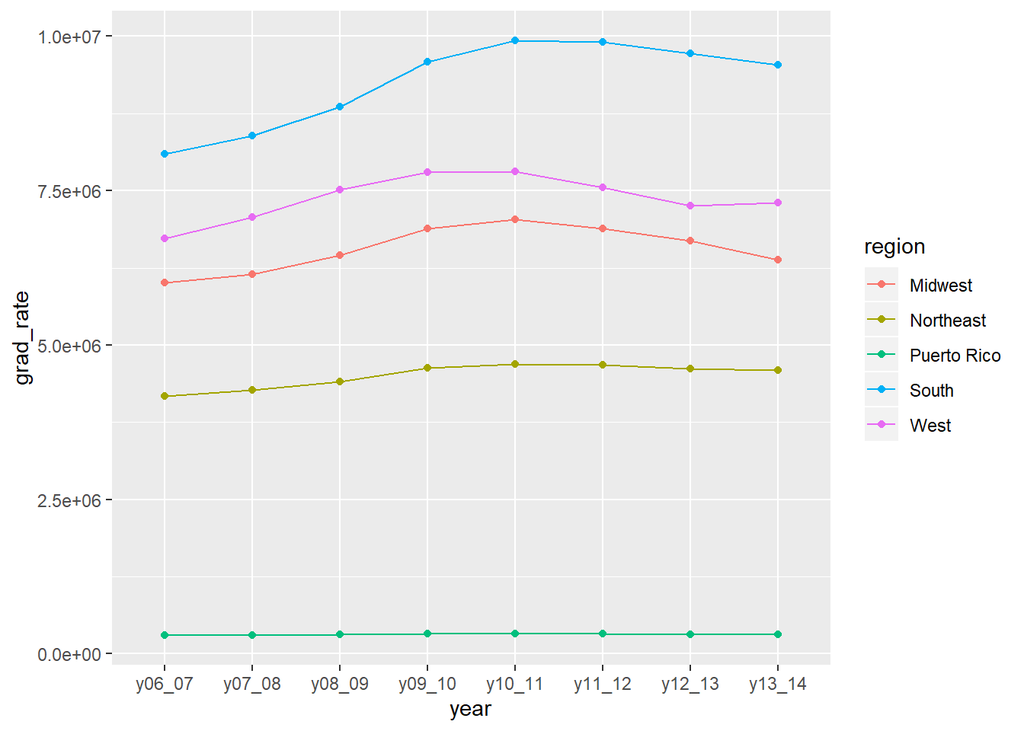

```r
#Chart each region's graduation rates per year
p<-ggplot(yearlydata1, aes(x=year, y=grad_rate, group=region)) +
  geom_line(aes(color=region))+
  geom_point(aes(color=region))
p
```

All regions except Puerto Rico experienced increased graduation rates from 2006 thru 2010. By 2014 the Midwest, Northeast and West had tapered down to roughly where they were in 2008.

```r
#Now we'll take the top 5 states that increased graduation percentages the most and do a series of their results
percentchangedata_sorted <- percentchangedata[order(percentchangedata$percent_change),]
top5increase <- tail(percentchangedata_sorted,5)
top5increase
```

```
##            state percent_change
## 48      Virginia      0.2568207
## 46          Utah      0.2709877
## 13         Idaho      0.4078684
## 30 New Hampshire      0.4861623
## 50 West Virginia      0.5332418
```

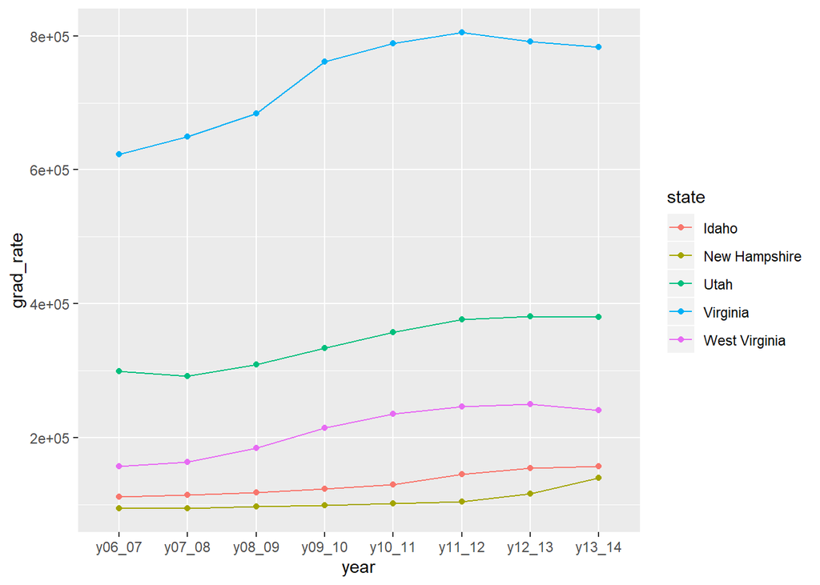

```r
#Chart the top 5 states with the highest percent change in graduation rates
top5_vector <- top5increase$state
top5increase_series <- subset(yearlydata, state == 'Virginia' | state == 'Utah' | state == 'Idaho' | state == 'New Hampshire' | state == 'West Virginia')

p<-ggplot(top5increase_series, aes(x=year, y=grad_rate, group=state)) +
  geom_line(aes(color=state))+
  geom_point(aes(color=state))
p
```

```r
#Now we'll take the top 5 states with decreased graduation percentages and create a series of their results
bottom5 <- head(percentchangedata_sorted,5)
bottom5
```

```
##                   state percent_change
## 9  District of Columbia    -0.24271898
## 23             Michigan    -0.04846662
## 41         Rhode Island    -0.03735096
## 49           Washington    -0.02760941
## 14             Illinois    -0.01451526
```

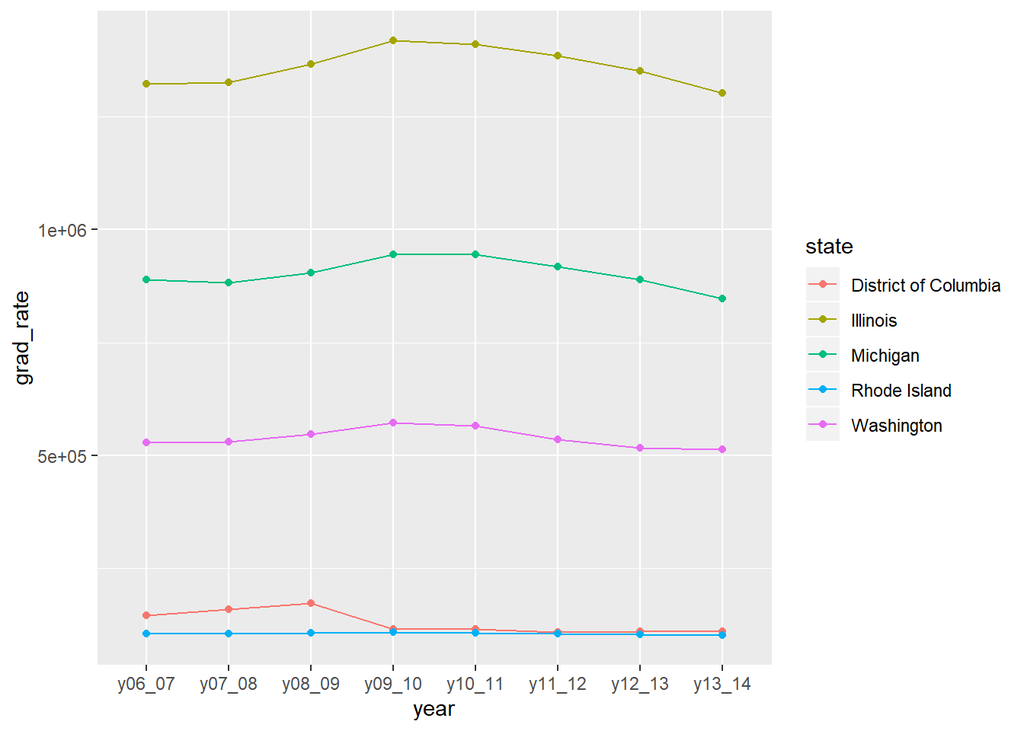

```r
#Chart the top 5 states with the lowest percent change in graduation rates
bottom5_vector <- bottom5$state
bottom5_series <- subset(yearlydata, state == 'District of Columbia' | state == 'Michigan' | state == 'Rhode Island' | state == 'Washington' | state == 'Illinois')

p<-ggplot(bottom5_series, aes(x=year, y=grad_rate, group=state)) +
  geom_line(aes(color=state))+
  geom_point(aes(color=state))
p
```

## Conclusions and Recommendations

2. Three of the five states that decreased in graduation rates by 2014, actually experienced an uptick in graduation rates during the middle years of 2008 - 2011.
3. The District of Columbia’s graduation rate dropped off sharply in 2010 and then remained steady at the lower rate thru 2014.

Recommendations for further study & analysis are… 1. Compare contrast conditions in Puerto Rico with the South to identify key factors that are influencing graduation rates.

2. Investigate what occurred in 2010 in the District of Columbia that caused what appear to be a permanent decline in graduation rates
3. Investigate the route causes for the three states (Michigan, Illinois, and Washington) to initially increase their grad rate, only to have it decline and become a decrease overall.